# Causal Inference & Prediction in Heterogenous Environments

Karim Carroum Sanz

March, 2020

*Advanced Topics in Applied Social Sciences - Master of Research - Universitat Pompeu Fabra*

*karim.carroum01@estudiant.upf.edu*

# 1 Introduction

Using data that has been gathered in different environments offers new ways of identifying causality, and improves prediction in targeted scenarios that are heterogeneous to the data in which the models are trained. Invariant causal prediction (Peters et al., 2015) identifies causal effects by exploiting the invariance in predictive accuracy of causal models among intervened scenarios. Anchor regression (Rothenhäusler et al., 2018) adds an intermediate minimization of predictive errors whose source is in the heterogeneity of the environment, which improves the predictions of ordinary least squares and instrumental variables for intermediate ranges of heterogeneity. I develop code in R to implement the latter approach, and apply it to a real-world example of citizens’ satisfaction. Comparing the results of anchor regression and invariant causal prediction showcases how the latter can dismantle false discoveries of causal effects suggested by the former.

# 2 Interventions on $X$

## 2.1 With a Confounder

This replicates Rothenhäusler et al. (2018) Example 2. Namely, we move to a train set where both $X,Y$ are partially determined by a confounder $H$, to a test set where $X$ experiences a shift (perturbation $\alpha$) on its exogenous anchor $A$.

$$\begin{align*}
&A \sim \textit{Rademacher}\\
&\varepsilon_H,\varepsilon_X,\varepsilon_Y\;\sim\;indep\;N(0,1)\\
&H\longleftarrow\varepsilon_H\;\;\;\;\;\;\;\;\;\;\;\;\;\;\;\;\;\;\;\;\;\;\;\;\;\;\;\;\;\;\; H\longleftarrow\varepsilon_H\\
&X\longleftarrow A+H+\varepsilon_X\quad\mathrm\quad\;\;\;\;\;\;\;\;\;\;X\longleftarrow \alpha+H+\varepsilon_X\\
&Y\longleftarrow X+2H+\varepsilon_Y\quad\mathrm\quad\;\;\;\;\;\;\;\;\;Y\longleftarrow X+2H+\varepsilon_Y
\end{align*}$$

Anchor Regression’s coefficient estimates are obtained from the following optimization:

$$\begin{align*}
b^\gamma := \text{argmin}_b\;\mathbb{E}[\,Y-Xb]\,+\gamma||\mathbb{E}[\,A^{t}(Y-Xb)]\,||_2^2\;\;\; (1)
\end{align*}$$

### 2.1.1 Anchor Regression Function

```r
library(extraDistr)    #To use the Rademacher distribution.
anchor.objective = function(param,gamma,a,y,x){
  n = length(y)
  predicted = rep(0,n); error = rep(0,n); penalty = rep(0,n)
  for (i in 1:n){
    predicted[i] = param[1] + param[2]*x[i]
    error[i] = predicted[i] - y[i]
    penalty[i] = (a[i]*(predicted[i]-y[i]))  #A is set to be a vector in the examples, but it can be extended to a matrix.
  }
  of = mean(error^2)+gamma*(mean(penalty))^2
  return(of)
}

anchor.this = function(param,gamma,a,y,x){
  return(nlminb(param,anchor.objective,gamma=gamma,a=a,y=y,x=x)$par)
}
```

### 2.1.2 Comparison Function between Anchor Regression, IV and OLS

The following function returns the MSEs obtained by AR, OLS and IV, depending on the size of the perturbation on $X$. Additionally, it returns the coefficient estimates for each of these methods, as well as the total computing time of the function. Its required inputs are the regularisation parameter $\gamma$ and the defining parameters of the range of perturbations that we want to analyse.

```r
comparison.ar.ls.iv = function(start,end,sep,gamma=5){
  start.time = Sys.time()
  mse.ar = c();  mse.ls = c();  mse.iv = c()
  perturbation.range= seq(start,end,sep);  fac = 1/sep

  #Train set
  n = 100000
  A = rsign(n); H = rep(0,n); X = rep(0,n); Y = rep(0,n)  #rsign(n) returns n random draws from A~Rademacher
  for (i in 1:n){
    H[i] = rnorm(1)
    X[i] = A[i] + H[i] + rnorm(1)
    Y[i] = X[i] + 2*H[i] + rnorm(1)
  }

  #AR, OLS and IV coefficients
  ls = lm(Y~X)  #OLS
  coeff.ls.beta0 = ls$coefficients[1]
  coeff.ls.beta1 = ls$coefficients[2]

  ar = anchor.this(c(3,3.7),gamma,a=A,y=Y,x=X)  #Anchor Regression
  coeff.ar.beta0 = ar[1]
  coeff.ar.beta1 = ar[2]

  iv = anchor.this(c(3,3.7),1000000,a=A,y=Y,x=X) #IV Regression (AR regression with gamma tending to infinite)
  coeff.iv.beta0 = iv[1]
  coeff.iv.beta1 = iv[2]

  #Test set
  nt = n/2
  Ht = rep(0,nt); Xt = rep(0,nt); Yt = rep(0,nt)
  for (i in 1:nt){
    Ht[i] = rnorm(1)
    Xt[i] = Ht[i] + rnorm(1)
    Yt[i] = 2*Ht[i] + rnorm(1)
  }

  Xtt = c();  Ytt = c()

  for (j in (1:length(perturbation.range))){

    for (i in 1:nt){ #Add perturbation to X
      Xtt[i] = Xt[i] + perturbation.range[j]
      Ytt[i] = Yt[i] + Xtt[i]
    }

    pred.ar = rep(0,nt); error.ar = rep(0,nt); pred.ls = rep(0,nt);
    error.ls = rep(0,nt); pred.iv = rep(0,nt); error.iv = rep(0,nt)
    for (l in 1:nt){
      pred.ar[l] = coeff.ar.beta0 + Xtt[l]*coeff.ar.beta1
      pred.ls[l] = coeff.ls.beta0 + Xtt[l]*coeff.ls.beta1
      pred.iv[l] = coeff.iv.beta0 + Xtt[l]*coeff.iv.beta1
      error.ar[l] = pred.ar[l]-Ytt[l]
      error.ls[l] = pred.ls[l]-Ytt[l]
      error.iv[l] = pred.iv[l]-Ytt[l]
    }
    mse.ar[j] = mean(error.ar^2);    mse.ls[j] = mean(error.ls^2);    mse.iv[j] = mean(error.iv^2)
  }

  end.time = Sys.time()
  total.time = end.time - start.time
  return(list("mse.ar"=mse.ar,"mse.ls"=mse.ls,"mse.iv"=mse.iv,"computing.time"=total.time,"gamma"=gamma,
              "coeff.ar"=list("coeff.ar.beta0"=coeff.ar.beta0,"coeff.ar.beta0"=coeff.ar.beta1),
              "coeff.ls"=list("coeff.ls.beta0"=coeff.ls.beta0,"coeff.ls.beta0"=coeff.ls.beta1),
              "coeff.iv"=list("coeff.iv.beta0"=coeff.iv.beta0,"coeff.iv.beta0"=coeff.iv.beta1)))
}
```

### 2.1.3 Results comparison

With the outputs of the function above, we can check how the MSE changes if we use AR, OLS or IV, for a range of perturbations.

```r
start = 0    #Define initial $\alpha$.
end = 4      #Define last $\alpha$ considered in the range.
sep = 0.1    #Set it lower to obtain a more smooth plot, but the function will take more time to run.
gamma = 5    #Regularisation parameter. Set by default to 5, as in Rothenhäusler et al. (2018).
set.seed(nchar("Randomness is an illusion"))
z = comparison.ar.ls.iv(start,end,sep,gamma)
```

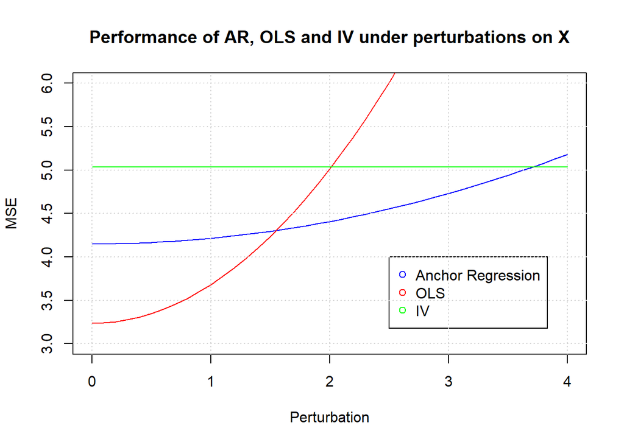

```r
plot(seq(start,end,sep),z$mse.ar,type = "l",col = "blue",main="Performance of AR, OLS and IV under perturbations on X",
     xlab = "Perturbation",ylab="MSE",xlim=c(0,4),ylim=c(3,6))
lines(seq(start,end,sep),z$mse.ls, col = "red")
lines(seq(start,end,sep),z$mse.iv, col = "green")
legend(2.5,4,legend=c("Anchor Regression","OLS","IV"),col=c("blue","red","green"), pch=c(1,1,1))
grid()
```

$\text{Figure 1. Performance of AR, OLS and IV for different perturbations on $X$, under the presence of a confounder.}$

Note that Anchor Regression outperforms outperforms OLS and IV for intermediate ranges of $\alpha$. However, if the perturbations are small, AR is outperformed by OLS, and if they are huge, it is outperformed by IV.

We can also compare $b^\gamma,b_{OLS},b_{IV}$.

```r
coeffs.ar.ls.iv = matrix(c(z$coeff.ar[1],z$coeff.ls[1],z$coeff.iv[1],z$coeff.ar[2],
                           z$coeff.ls[2],z$coeff.iv[2]),nrow=3,ncol=2)
colnames(coeffs.ar.ls.iv) = c("beta0","beta1")
rownames(coeffs.ar.ls.iv) = c("Anchor Regression", "OLS Regression", "IV Regression")
print(coeffs.ar.ls.iv)
```

```
##                   beta0        beta1
## Anchor Regression 0.002386408  1.253927
## OLS Regression    0.0007947896 1.665079
## IV Regression     0.003346494  1.005565
```

We can see that $b_1^\gamma\in\{b_{1_{IV}},b_{1_{OLS}}\}$ as its estimation is the result of an intermediate regularisation regarding errors coming from a partial adjustment to perturbations. Note that only $b_{IV}=b$ while $b^\gamma\neq b$ and obviously $b_{OLS}\neq b$. This showcases the tradeoff between the win in predictive accuracy (at least for a range of the perturbations, which can be more or less realistic depending on the case) vs the loss in causal interpretation faced by anchor regression when there exists a confounder.

## 2.2 Without a Confounder

$$\begin{align*}
&A \sim \textit{Rademacher}\\
&\varepsilon_X,\varepsilon_Y\;\sim\;indep\;N(0,1)\\
&X\longleftarrow A+\varepsilon_X\quad\mathrm\quad\;\;\;\;\;\;\;\;\;X\longleftarrow \alpha+\varepsilon_X\\
&Y\longleftarrow X+\varepsilon_Y\quad\mathrm\quad\;\;\;\;\;\;\;\;\;Y\longleftarrow X+\varepsilon_Y
\end{align*}$$

### 2.2.1 Comparison Function between Anchor Regression, IV and OLS

The only change is that $H$ is removed. The simulation will show that, trivially, in the absence of confounders, a shift in $X$ does not result in a bias in its estimated coefficient neither via AR nor OLS (and of course nor IV). Since the three estimators will be the same, we can conclude (according to Theorem 4 in Rothenhäusler et al., 2018) that there exists causality between $X,Y$.

```r
comparison.ar.ls.iv.no.confounder = function(start,end,sep,gamma=5){
  start.time = Sys.time()
  mse.ar = c();  mse.ls = c();  mse.iv = c()
  perturbation.range= seq(start,end,sep); fac = 1/sep

  #Train set
  n = 100000
  A = rsign(n); X = rep(0,n); Y = rep(0,n)
  for (i in 1:n){
    X[i] = A[i] + rnorm(1)
    Y[i] = X[i] + rnorm(1)
  }

  #AR, OLS and IV coefficients
  ls = lm(Y~X)  #OLS
  coeff.ls.beta0 = ls$coefficients[1]
  coeff.ls.beta1 = ls$coefficients[2]

  ar = anchor.this(c(3,3.7),gamma,a=A,y=Y,x=X)  #Anchor Regression
  coeff.ar.beta0 = ar[1]
  coeff.ar.beta1 = ar[2]

  iv = anchor.this(c(3,3.7),1000000,a=A,y=Y,x=X) #IV Regression
  coeff.iv.beta0 = iv[1]
  coeff.iv.beta1 = iv[2]

  #Test set
  nt = n/2
  Ht = rep(0,nt); Xt = rep(0,nt); Yt = rep(0,nt)
  for (i in 1:nt){
    Xt[i] = rnorm(1)
    Yt[i] = rnorm(1)
  }

  Xtt = c(); Ytt = c()

  for (j in (1:length(perturbation.range))){

    for (i in 1:nt){ #Add perturbation to X
      Xtt[i] = Xt[i] + perturbation.range[j]
      Ytt[i] = Yt[i] + Xtt[i]
    }

    pred.ar = rep(0,nt); error.ar = rep(0,nt); pred.ls = rep(0,nt);
    error.ls = rep(0,nt); pred.iv = rep(0,nt); error.iv = rep(0,nt)
    for (l in 1:nt){
      pred.ar[l] = coeff.ar.beta0 + Xtt[l]*coeff.ar.beta1
      pred.ls[l] = coeff.ls.beta0 + Xtt[l]*coeff.ls.beta1
      pred.iv[l] = coeff.iv.beta0 + Xtt[l]*coeff.iv.beta1
      error.ar[l] = pred.ar[l]-Ytt[l]
      error.ls[l] = pred.ls[l]-Ytt[l]
      error.iv[l] = pred.iv[l]-Ytt[l]
    }
    mse.ar[j] = mean(error.ar^2);    mse.ls[j] = mean(error.ls^2);    mse.iv[j] = mean(error.iv^2)
  }

  end.time = Sys.time()
  total.time = end.time - start.time
  return(list("mse.ar"=mse.ar,"mse.ls"=mse.ls,"mse.iv"=mse.iv,"computing.time"=total.time,"gamma"=gamma,
              "coeff.ar"=list("coeff.ar.beta0"=coeff.ar.beta0,"coeff.ar.beta0"=coeff.ar.beta1),
              "coeff.ls"=list("coeff.ls.beta0"=coeff.ls.beta0,"coeff.ls.beta0"=coeff.ls.beta1),
              "coeff.iv"=list("coeff.iv.beta0"=coeff.iv.beta0,"coeff.iv.beta0"=coeff.iv.beta1)))
}
```

### 2.2.2 Results Comparison

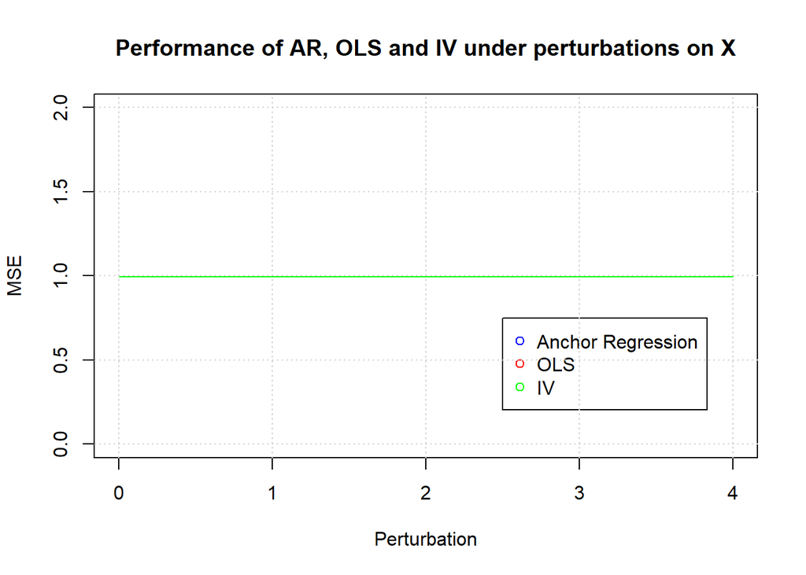

```r
start = 0; end = 4; sep = 0.1; gamma = 5
set.seed(nchar("Randomness is an illusion"))
z = comparison.ar.ls.iv.no.confounder(start,end,sep,gamma)

plot(seq(start,end,sep),z$mse.ar,type = "l",col = "blue",main="Performance of AR, OLS and IV under perturbations on X",
     xlab = "Perturbation",ylab="MSE",xlim=c(0,4),ylim=c(0,2))
lines(seq(start,end,sep),z$mse.ls, col = "red")
lines(seq(start,end,sep),z$mse.iv, col = "green")
legend(2.5,0.75,legend=c("Anchor Regression","OLS","IV"),col=c("blue","red","green"), pch=c(1,1,1))
grid()
```

$\text{Figure 2. Performance of AR, OLS and IV for different perturbations on $X$, without the presence of a confounder.}$

Note that all the MSEs obtained by the three methods for each level of perturbation are the same (that’s why we only see the green line, since it is the last one to be added to the plot).

```r
coeffs.ar.ls.iv = matrix(c(z$coeff.ar[1],z$coeff.ls[1],z$coeff.iv[1],z$coeff.ar[2],
                           z$coeff.ls[2],z$coeff.iv[2]),nrow=3,ncol=2)
colnames(coeffs.ar.ls.iv) = c("beta0","beta1")
rownames(coeffs.ar.ls.iv) = c("Anchor Regression", "OLS Regression", "IV Regression")
print(coeffs.ar.ls.iv)
```

```
##                   beta0        beta1
## Anchor Regression -0.004533904 1.002515
## OLS Regression    -0.004532356 1.002237
## IV Regression     -0.004535139 1.002625
```

We can see that $b^\gamma\approx b_{OLS}\approx b_{IV}$. According to Theorem $4$ in Rothenhäusler et al. (2018), this implies that there is causality between $X$ and $Y$. This shows how Anchor Regression, via the specification in ($1$), is able to detect causality in the absence of the confounder $H$.

# 3 Interventions on $H$

In this case, we have that the confounder $H$, which affects both $X$ and $Y$, is perturbed by $\alpha$.
$$\begin{align*}
&A \sim \textit{Rademacher}\\
&\varepsilon_H,\varepsilon_X,\varepsilon_Y\;\sim\;indep\;N(0,1)\\
&H\longleftarrow A+\varepsilon_H\;\;\;\;\;\;\;\;\;\;\;\;\;\;\;\;\;\;\;\;\;\;\;\; H\longleftarrow\alpha+\varepsilon_H\\
&X\longleftarrow H+\varepsilon_X\quad\mathrm\quad\;\;\;\;\;\;\;\;\;\;\;\;\;\;\;\;\;X\longleftarrow H+\varepsilon_X\\
&Y\longleftarrow X+2H+\varepsilon_Y\quad\mathrm\quad\;\;\;\;\;\;\;\;\;Y\longleftarrow X+2H+\varepsilon_Y
\end{align*}$$

## 3.1 Comparison Function between Anchor Regression, IV, OLS and the Direct Causal Effect

In addition to AR and OLS, this example displays the predictive performance of using the direct causal effect (i.e. setting $\hat{b}=1$). The function modifies the one for the shift in $X$ by adding the direct causal effect, and implementing the perturbations in $H$ instead than in $X$.

```r
comparison.ar.ls.iv.ca = function(start,end,sep,gamma){
  start.time = Sys.time()
  mse.ar = c();  mse.ls = c(); mse.iv = c(); mse.ca = c();  perturbation.range= seq(start,end,sep);  fac = 1/sep

  #Train set
  n = 100000
  A = rsign(n); H = rep(0,n); X = rep(0,n); Y = rep(0,n)
  for (i in 1:n){
    H[i] = A[i] + rnorm(1)
    X[i] = H[i] + rnorm(1)
    Y[i] = X[i] + 2*H[i] + rnorm(1)
  }

  #AR, OLS and Direct Causal Effect coefficients
  ls = lm(Y~X)  #OLS
  coeff.ls.beta0 = ls$coefficients[1]
  coeff.ls.beta1 = ls$coefficients[2]

  ar = anchor.this(c(3,3.7),gamma,a=A,y=Y,x=X)  #Anchor Regression
  coeff.ar.beta0 = ar[1]
  coeff.ar.beta1 = ar[2]

  iv = anchor.this(c(3,3.7),1000000,a=A,y=Y,x=X) #IV Regression
  coeff.iv.beta0 = iv[1]
  coeff.iv.beta1 = iv[2]

  coeff.ca.beta0 = 0  #Direct Causal Effect
  coeff.ca.beta1 = 1

  #Test set
  nt = n/2
  Ht = rep(0,nt); Xt = rep(0,nt); Yt = rep(0,nt); Htt = rep(0,nt); Xtt = rep(0,nt); Ytt = rep(0,nt)
  for (i in 1:nt){
    Ht[i] = rnorm(1)
    Xt[i] = rnorm(1)
    Yt[i] = rnorm(1)
  }

  for (j in (1:length(perturbation.range))){

    for (i in 1:nt){ #Add perturbation to H
      Htt[i] = Ht[i] + perturbation.range[j]
      Xtt[i] = Xt[i] + Htt[i]
      Ytt[i] = Yt[i] + Xtt[i] + 2*Htt[i]
    }

    pred.ar = rep(0,nt); pred.ls = rep(0,nt); pred.iv = rep(0,nt); pred.ca = rep(0,nt);
    error.ar = rep(0,nt); error.ls = rep(0,nt); error.iv = rep(0,nt); error.ca = rep(0,nt)

    for (l in 1:nt){
      pred.ar[l] = coeff.ar.beta0 + Xtt[l]*coeff.ar.beta1
      pred.ls[l] = coeff.ls.beta0 + Xtt[l]*coeff.ls.beta1
      pred.iv[l] = coeff.iv.beta0 + Xtt[l]*coeff.iv.beta1
      pred.ca[l] = coeff.ca.beta0 + Xtt[l]*coeff.ca.beta1
      error.ar[l] = pred.ar[l]-Ytt[l]
      error.ls[l] = pred.ls[l]-Ytt[l]
      error.iv[l] = pred.iv[l]-Ytt[l]
      error.ca[l] = pred.ca[l]-Ytt[l]
    }

    mse.ar[j] = mean(error.ar^2); mse.ls[j] = mean(error.ls^2); mse.iv[j] = mean(error.iv^2); mse.ca[j] = mean(error.ca^2)

  }

  end.time = Sys.time()
  total.time = end.time - start.time
  return(list("mse.ar"=mse.ar,"mse.ls"=mse.ls,"mse.ca"=mse.ca,
              "coeff.ar"=list("coeff.ar.beta0"=coeff.ar.beta0,"coeff.ar.beta0"=coeff.ar.beta1),
              "coeff.ls"=list("coeff.ls.beta0"=coeff.ls.beta0,"coeff.ls.beta0"=coeff.ls.beta1),
              "coeff.iv"=list("coeff.iv.beta0"=coeff.iv.beta0,"coeff.iv.beta0"=coeff.iv.beta1),
              "coeff.ca"=list("coeff.ca.beta0"=coeff.ca.beta0,"coeff.ca.beta0"=coeff.ca.beta1),
              "computing.time"=total.time,"gamma"=gamma))
}
```

## 3.2 Results Comparison

```r
start = 0; end = 4; sep = 0.1; gamma = 5
set.seed(nchar("Randomness is an illusion"))
z = comparison.ar.ls.iv.ca(start,end,sep,gamma)
```

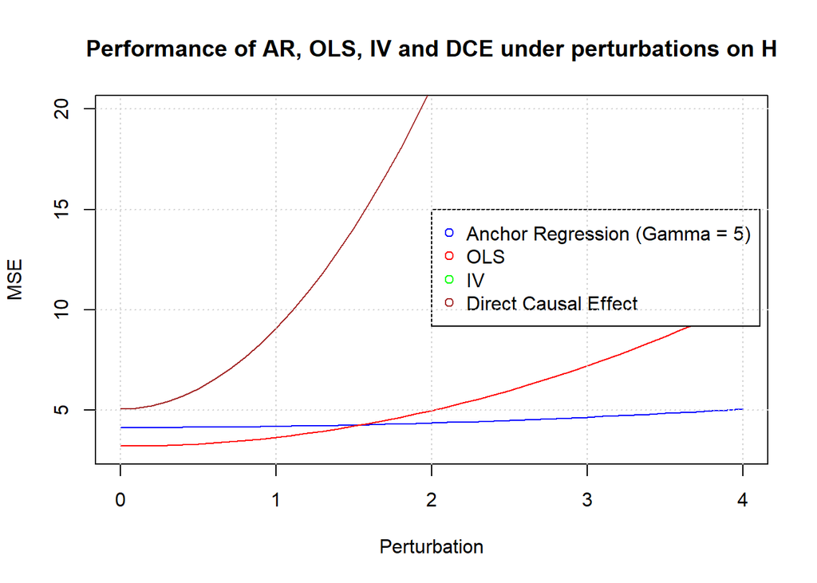

```r
plot(seq(start,end,sep),z$mse.ar,type = "l",col = "blue",main="Performance of AR, OLS, IV and DCE under perturbations on H", xlab = "Perturbation",ylab="MSE",xlim=c(0,4),ylim=c(3,20))
lines(seq(start,end,sep),z$mse.ls, col = "red")
lines(seq(start,end,sep),z$mse.iv, col = "green")  #This line does not show, but it is horizontal at MSE = 5.
lines(seq(start,end,sep),z$mse.ca, col = "brown")
legend(2,15,legend=c("Anchor Regression (Gamma = 5)","OLS","IV","Direct Causal Effect"), col= c("blue", "red", "green", "brown"), pch=c(1,1,1,1))
grid()
```

$\text{Figure 3. Performance of AR, OLS, IV and DCE for different perturbations on H.}$

We can see that setting $\hat{b}$ as the DCE is clearly outperformed, in terms of predictive ability, by all the other approaches, for any range of perturbations. The ranking of the predictive performance among AR, OLS and IV, along the range of perturbations, is the same as when $X$ is the perturbed variable.

The order of the magnitude of the MSE yielded by those three approaches is the same as in the previous case, which showcases that AR’s predictive performance is the same both for scenarios where the predictor or the confounder are perturbed. Nevertheless, as the coefficients in the table below show, the bias of the AR coefficient estimates is considerable greater than the one resulting from the previous case (namely, $b_1^\gamma|H(\alpha)=2.75>b_1^\gamma|X(\alpha)=1.26>b=1$).

This is because, given the structure equation model, the effect of the shift in $H$ on $Y$ is bigger than an the effect of a shit in $X$, since now $Y$ is affected via $H$ twice (first directly through $2H$, and then by $X$). Since the covariability of $Y$ with $X$ is bigger than before while the variability of $X$ remains the same, the regression overestimates more than for the previous case the effect of $X$ on $Y$.

```r
coeffs.ar.ls.iv.ca = matrix(c(z$coeff.ar[1],z$coeff.ls[1],z$coeff.iv[1],z$coeff.ca[1],z$coeff.ar[2],
                           z$coeff.ls[2],z$coeff.iv[2],z$coeff.ca[2]),nrow=4,ncol=2)
colnames(coeffs.ar.ls.iv.ca) = c("beta0","beta1")
rownames(coeffs.ar.ls.iv.ca) = c("Anchor Regression", "OLS Regression", "IV Regression", "Direct Causal Effect")
print(coeffs.ar.ls.iv.ca)
```

```
##                      beta0        beta1
## Anchor Regression    -0.003433769 2.757224
## OLS Regression       -0.001780745 2.330399
## IV Regression        -0.004431123 3.015053
## Direct Causal Effect 0            1
```

# 4 Real-world example: Happiness ~ Education Satisfaction

$$\begin{align*}
&A_i\in\{0,1\}\;\;\forall i\in\{1,...,n_{\text{train}}\}\\
&\varepsilon_H,\varepsilon_X,\varepsilon_Y\;\sim\;indep\;N(0,\sigma_k)\;\;\text{for}\;\;k\in\{H,X,Y\}\\
&H\longleftarrow A+\varepsilon_H\;\;\;\;\;\;\;\;\;\;\;\;\;\;\;\;\;\;\;\;\;\;\;\;\;\;\;\;\;\;\; H\longleftarrow\phi\cdot\alpha+\varepsilon_H\\
&X\longleftarrow\eta\cdot H+\varepsilon_X\quad\mathrm\quad\;\;\;\;\;\;\;\;\;\;\;\;\;\;\;\;\;\;\;X\longleftarrow\eta\cdot H+\varepsilon_X\\
&Y\longleftarrow b_1\cdot X+\delta\cdot H+\varepsilon_Y\quad\mathrm\quad\;\;\;\;\;\;\;\;Y\longleftarrow b_1\cdot X+\delta\cdot H+\varepsilon_Y
\end{align*}$$

```r
### Data setup

datapath = "C:/Users/karim/OneDrive/Escritorio"
d = read.csv(file.path(datapath, "germany.csv"), sep = ",")
d = d[,(dim(d)[2]-2):dim(d)[2]]
d[,2] = d[,2]-mean(d[,2]); d[,3] = d[,3]-mean(d[,3]) #We center X and Y at zero.
colnames(d)   #X as education satisfaction, Y as happiness, A as round (period at which each survey was taken).
```

```
## [1] "round"  "happy"  "stfedu"
```

```r
train = d[which(d$round==0|d$round==1),]   #Select the first two rounds of the survey as the train set.
test2 = d[which(d$round==2),]              #As many test sets as round remaining.
test3 = d[which(d$round==3),]
test4 = d[which(d$round==4),]
test5 = d[which(d$round==5),]
test6 = d[which(d$round==6),]
```

## 4.1 Coefficient Comparison

```r
A = train[,1]; X = train[,3] ; Y = train[,2]; gamma = 5

ls = lm(Y~X)  #OLS Regression
coeff.ls.beta0 = ls$coefficients[1]
coeff.ls.beta1 = ls$coefficients[2]

ar = anchor.this(c(1,1),gamma,a=A,y=Y,x=X)  #Anchor Regression
coeff.ar.beta0 = ar[1]
coeff.ar.beta1 = ar[2]
iv = anchor.this(c(1,1),1000000,a=A,y=Y,x=X) #IV Regression
coeff.iv.beta0 = iv[1]
coeff.iv.beta1 = iv[2]

coeffs.ar.ls.iv = matrix(c(coeff.ar.beta0,coeff.ls.beta0,coeff.iv.beta0,coeff.ar.beta1,
                           coeff.ls.beta1,coeff.iv.beta1),nrow=3,ncol=2)
colnames(coeffs.ar.ls.iv) = c("beta0","beta1")
rownames(coeffs.ar.ls.iv) = c("Anchor Regression", "OLS Regression", "IV Regression")
print(coeffs.ar.ls.iv)
```

```
##                         beta0     beta1
## Anchor Regression  0.03728047 0.1275844
## OLS Regression    -0.01612349 0.1218267
## IV Regression      0.10910295 0.1353286
```

$b_{1_{IV}}$ and $b_{1_{OLS}}$ are very similar, whigh suggests that, if the assumptions required by theorem 1 hold, there is a causal relation between the happiness of German citizens and their degree of satisfaction with their education.

## 4.2 MSE Performance Comparison

```r
tests = c(test2,test3,test4,test5,test6)
mse.ar = c(); mse.ls = c(); mse.iv = c()
for (test in 1:5){

  l = length(tests[[test*3-2]])
  x = tests[[test*3]]
  y = tests[[test*3-1]]

  pred.ar = rep(0,l)
  pred.ls = rep(0,l)
  pred.iv = rep(0,l)
  error.ar = rep(0,l)
  error.ls = rep(0,l)
  error.iv = rep(0,l)

  for (i in 1:l){

    pred.ar[i] = coeff.ar.beta0 + coeff.ar.beta1*x[i]
    pred.ls[i] = coeff.ls.beta0 + coeff.ls.beta1*x[i]
    pred.iv[i] = coeff.iv.beta0 + coeff.iv.beta1*x[i]
    error.ar[i] = pred.ar[i] - y[i]
    error.ls[i] = pred.ls[i] - y[i]
    error.iv[i] = pred.iv[i] - y[i]

  }

  mse.ar[test] = mean(error.ar^2)
  mse.ls[test] = mean(error.ls^2)
  mse.iv[test] = mean(error.iv^2)

}
```

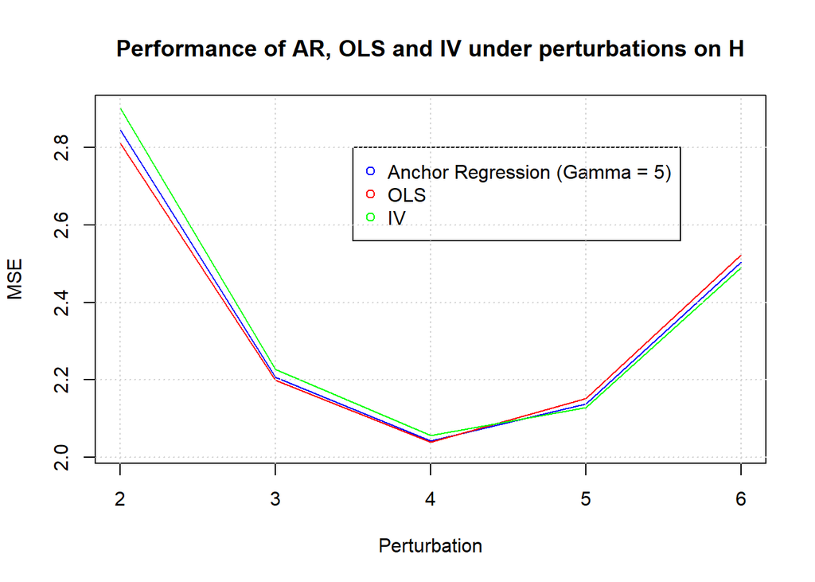

```r
plot(2:6,mse.ar,type = "l",col = "blue",main="Performance of AR, OLS and IV under perturbations on H", xlab = "Perturbation",ylab="MSE",xlim=c(2,6),ylim=c(2.02,2.9))
lines(2:6,mse.ls,col="red")
lines(2:6,mse.iv,col="green")
legend(3.5,2.8,legend=c("Anchor Regression (Gamma = 5)","OLS","IV"), col= c("blue", "red", "green"), pch=c(1,1,1))
grid()
```

$\text{Figure 4. Performance of AR, OLS, and IV for different perturbations on H, when we evaluate the impact of stfedu on happiness on Germany.}$

When the perturbation is small (one round ahead prediction), OLS outperforms IV and AR. For intermediate perturbations (two and three rounds ahead predictions), AR and OLS yield almost the same MSE, wich is below that achieved by IV. For large perturbations (four and five rounds ahead predictions), IV is the best performer, and AR yields a smaller MSE than OLS. Note though that the differences between the predictive ability of these methods are not very big, which follows from the above-mentioned fact that their coefficient estimates are very similar.

# 5 Invariant Causal Prediction (ICP)

```r
library(InvariantCausalPrediction)
z = ICP(X=d[,3],Y=d[,2],ExpInd=d[,1])  #Using the whole (train and test) set.
```

```
##
##  accepted set of variables 1
```

```r
print(z)
```

```
##
##  Invariant Linear Causal Regression at level 0.01 (including multiplicity correction for the number of variables)
##  Variable Variable_1 shows a significant causal effect
##
##              LOWER BOUND  UPPER BOUND  MAXIMIN EFFECT  P-VALUE
## Variable_1         0.07         0.19            0.07   0.0092 **
## ---
## Signif. codes:  0 '***' 0.001 '**' 0.01 '*' 0.05 '.' 0.1 ' ' 1
```

```r
print(z$Coeff)
```

```
## [[1]]
## XVariable_1
##   0.1317202
```

```r
z.ols = lm(d[,2]~d[,3])
summary(z.ols)
```

```
##
## Call:
## lm(formula = d[, 2] ~ d[, 3])
##
## Residuals:
##     Min      1Q  Median      3Q     Max
## -7.0291 -0.7657  0.2343  0.9709  2.7612
##
## Coefficients:
##               Estimate Std. Error t value Pr(>|t|)
## (Intercept) -1.621e-16  4.572e-02   0.000        1
## d[, 3]       1.317e-01  2.131e-02   6.182 8.83e-10 ***
## ---
## Signif. codes:  0 '***' 0.001 '**' 0.01 '*' 0.05 '.' 0.1 ' ' 1
##
## Residual standard error: 1.536 on 1127 degrees of freedom
## Multiple R-squared:  0.0328, Adjusted R-squared:  0.03194
## F-statistic: 38.22 on 1 and 1127 DF,  p-value: 8.834e-10
```

Using the whole set, ICP discovers a significant causal effect between stfedu and happiness. As explained in the paper, the coefficient estimated by ICP is the same yielded by OLS, but the former estimates a considerably wider confidence interval that takes into account the differences between environments in predictions by the model.

```r
z = ICP(X=train[,3],Y=train[,2],ExpInd=train[,1])  #Using the test set.
```

```
##
##  accepted empty set
##  accepted set of variables
##  accepted set of variables 1
```

```r
print(z)
```

```
##
##  Invariant Linear Causal Regression at level 0.01 (including multiplicity correction for the number of variables)
##
##              LOWER BOUND  UPPER BOUND  MAXIMIN EFFECT  P-VALUE
## Variable_1         0.00         0.24            0.00     0.11
```

```r
print(z$Coeff)
```

```
## [[1]]
## XVariable_1
##   0.1218267
```

```r
z.ols = lm(train[,2]~train[,3])
summary(z.ols)
```

```
##
## Call:
## lm(formula = train[, 2] ~ train[, 3])
##
## Residuals:
##     Min      1Q  Median      3Q     Max
## -6.9977 -0.7540  0.2460  0.8805  2.7333
##
## Coefficients:
##             Estimate Std. Error t value Pr(>|t|)
## (Intercept) -0.01612    0.08956  -0.180  0.85725
## train[, 3]   0.12183    0.04217   2.889  0.00413 **
## ---
## Signif. codes:  0 '***' 0.001 '**' 0.01 '*' 0.05 '.' 0.1 ' ' 1
##
## Residual standard error: 1.54 on 315 degrees of freedom
## Multiple R-squared:  0.02581,    Adjusted R-squared:  0.02272
## F-statistic: 8.346 on 1 and 315 DF,  p-value: 0.004133
```

Using only the train set, ICP does not discover a significant causal effect. Recall that the train set only has two environments, and so the chances that one of them is appealingly intervened are lower than those of findings such perturbations if we consider the seven environments of the whole dataset. An interesting remark is that, while using the whole set, both the confidence intervals estimated by ICP and OLS identify a significant causal effect, if we only employ the train set (consisting in just two environments), OLS keeps identifying the causal effect, but ICP does not anymore.